# IE6400 Foundations of Data Analytics Engineering

# Fall 2023

### Module 3: Linear Algebra Part-1

### Linear Algebra Overview

Linear algebra is a branch of mathematics that deals with vectors, vector spaces, linear transformations, and systems of linear equations. It provides the foundation for many areas in mathematics and has applications in various fields such as physics, computer science, engineering, economics, and more.

#### Fundamental Concepts and Topics

#### 1. Scalars, Vectors, and Matrices

- **Scalar:** A single number, usually denoted as ( c ) or ( k ).
- **Vector:** An ordered list of numbers. It can be thought of as a point in space, with each number indicating its position along a certain axis.
- **Matrix:** A rectangular array of numbers. Matrices are used to represent linear transformations, systems of linear equations, and more.

#### 2. Vector Spaces

A set of vectors that is closed under vector addition and scalar multiplication, and satisfies certain axioms like associativity, commutativity, and the existence of an additive identity (zero vector) and additive inverses.

#### 3. Linear Transformations

Functions that map vectors from one vector space to another while preserving the operations of vector addition and scalar multiplication.

#### 4. Dot Product and Cross Product

- **Dot Product:** A scalar-valued function that takes two vectors and returns a scalar. It measures the cosine similarity between two vectors.
- **Cross Product:** A vector-valued function that takes two vectors in three-dimensional space and returns a vector perpendicular to both.

#### 5. Determinants

A scalar value derived from a square matrix. It has various applications, including determining if a matrix is invertible and computing the volume of a parallelepiped.

#### 6. Eigenvalues and Eigenvectors

Given a linear transformation (or matrix), eigenvectors are non-zero vectors that only change by a scalar factor (the eigenvalue) when that transformation is applied.

#### 7. Matrix Factorizations

Decomposing a matrix into a product of simpler matrices, such as LU decomposition, QR decomposition, and singular value decomposition (SVD).

#### 8. Systems of Linear Equations

A collection of linear equations, often represented in matrix form as ( Ax = b ), where ( A ) is a matrix, ( x ) is a column vector of variables, and ( b ) is a column vector of numbers.

#### 9. Orthogonality

Vectors are orthogonal if their dot product is zero. An orthonormal set of vectors is orthogonal and each vector has a magnitude of 1.

#### 10. Linear Independence

A set of vectors is linearly independent if no vector in the set can be expressed as a linear combination of the other vectors.

#### 11. Basis and Dimension

A basis of a vector space is a set of linearly independent vectors that span the space. The number of vectors in a basis is called the dimension of the space.

#### Applications

Linear algebra provides the tools and techniques to analyze and understand linear relationships, making it a cornerstone in many scientific and engineering disciplines. For example, in computer graphics, linear algebra is used to transform and project 3D models onto a 2D screen. In data science and machine learning, it's used in various algorithms and methods like principal component analysis (PCA) and singular value decomposition (SVD).

### Vector

A vector is a tuple of one or more values called scalars.

Vectors are often represented using a lowercase character such as $v$.  
For Example: $v = (v1,v2,v3). $Where $v1, v2, v3$ are scalar values, often real values.

Vectors are also shown using a vertical representation or a column.  
for example: $v = \begin{pmatrix} v1\\ v2\\ v3 \end{pmatrix}$

The heart of linear algebra is in two operations-both with vectors. We add vectors to get $v$ + $w$. We multiply them by numbers $c$ and $d$ to get $cv$ and $d w$. Combining those two operations (adding $cv$ to $dw$) gives the linear combination $cv + d w$.

#### Exercise 1 Creating Vectors from Arrays using Python

#### Problem Statement

Imagine you are working with a dataset containing the monthly sales figures of a retail store for the year 2023. Your task is to convert these sales figures, which are stored in an array, into a vector format for further analysis.

**Objective:** Convert the given sales array into a vector and visualize the sales trend over the months.

#### Step 1: Importing Necessary Libraries

```python
import numpy as np
import matplotlib.pyplot as plt
```

#### Step 2: Generating the Dataset

We'll create a dataset representing the monthly sales figures for the year 2023.

```python
# Generating sample data
np.random.seed(0)
months = ["Jan", "Feb", "Mar", "Apr", "May", "Jun", "Jul", "Aug", "Sep", "Oct", "Nov", "Dec"]
sales_array = np.random.randint(5000, 10000, 12)  # Random sales figures between 5000 and 10000
print(sales_array)
```

```
[7732 7607 6653 8264 9931 9859 6033 9373 8468 5705 7599 7135]
```

#### Step 3: Converting Array to Vector

In Python, arrays and vectors are essentially treated the same when using the `numpy` library. However, for the sake of this exercise, we'll demonstrate the conversion.

```python
# Converting array to vector
sales_vector = np.array(sales_array).reshape(-1,1)
print(sales_vector)
```

```
[[7732]
 [7607]
 [6653]
 [8264]
 [9931]
 [9859]
 [6033]
 [9373]
 [8468]
 [5705]
 [7599]
 [7135]]
```

#### Step 4: Visualization

We'll visualize the sales trend over the months to get an understanding of the sales pattern.

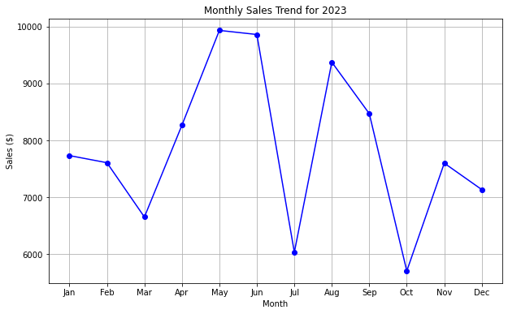

```python
# Plotting the sales trend
plt.figure(figsize=(10, 6))
plt.plot(months, sales_vector, marker='o', linestyle='-', color='blue')
plt.title('Monthly Sales Trend for 2023')
plt.xlabel('Month')
plt.ylabel('Sales ($)')
plt.grid(True)
plt.show()
```

#### Interpretation

From the visualization:

- Observe the months where sales peaked and the months where sales were relatively low.
- This trend visualization can help the retail store in forecasting and inventory management for the upcoming years.

#### Conclusion

Through this exercise, we've converted an array of sales figures into a vector format and visualized the monthly sales trend. This basic operation forms the foundation for many advanced data analysis and linear algebra operations in Python.

#### **Exercise 2**

The empty() function will create a new array of the specified shape. The argument to the function is an array or tuple that specifies the length of each dimension of the array to create. The values or content of the created array will be random and will need to be assigned before use. The example below creates an empty 3 × 3 two-dimensional array.

```python
from numpy import empty
a = empty([3,3])
print(a)
```

```
[[1. 0. 0.]
 [0. 1. 0.]
 [0. 0. 1.]]
```

#### **Exercise 3**

The zeros() function will create a new array of the specified size with the contents filled with zero values. The argument to the function is an array or tuple that specifies the length of each dimension of the array to create. The example below creates a 3 × 5 zero two-dimensional array.

```python
from numpy import zeros
a = zeros([3,5])
print(a)
```

```
[[0. 0. 0. 0. 0.]
 [0. 0. 0. 0. 0.]
 [0. 0. 0. 0. 0.]]
```

#### **Exercise 4**

The ones() function will create a new array of the specified size with the contents filled with one values. The argument to the function is an array or tuple that specifies the length of each dimension of the array to create. The example below creates a 5-element one-dimensional array.

```python
from numpy import ones
a = ones([5])
print(a)
```

```
[1. 1. 1. 1. 1.]
```

### Combining Vectors

NumPy provides many functions to create new arrays from existing arrays. Let’s look at two of the most popular functions you may need or encounter.

#### **Vertical Stack**

Given two or more existing arrays, you can stack them vertically using the vstack() function. For example, given two one-dimensional arrays, you can create a new two-dimensional array with two rows by vertically stacking them. This is demonstrated in the example below.

#### **Exercise 5**

```python
# create array with vstack
from numpy import array
from numpy import vstack
# create first array
a1 = array([1,2,3])
print(a1)
```

```
[1 2 3]
```

```python
# create second array
a2 = array([4,5,6])
print(a2)
```

```
[4 5 6]
```

```python
# vertical stack
a3 = vstack((a1, a2))
print(a3)
print(a3.shape)
```

```
[[1 2 3]
 [4 5 6]]
(2, 3)
```

Running the example first prints the two separately defined one-dimensional arrays. The arrays are vertically stacked resulting in a new 2 × 3 array, the contents and shape of which are printed.

#### **Horizontal Stack**

Given two or more existing arrays, you can stack them horizontally using the hstack() function. For example, given two one-dimensional arrays, you can create a new one-dimensional array or one row with the columns of the first and second arrays concatenated. This is demonstrated in the example below.

#### **Exercise 6**

```python
# create array with hstack
from numpy import array
from numpy import hstack
# create first array
a1 = array([1,2,3])
print(a1)
```

```
[1 2 3]
```

```python
# create second array
a2 = array([4,5,6])
print(a2)
```

```
[4 5 6]
```

```python
# create horizontal stack
a3 = hstack((a1, a2))
print(a3)
print(a3.shape)
```

```
[1 2 3 4 5 6]
(6,)
```

Running the example first prints the two separately defined one-dimensional arrays. The arrays are then horizontally stacked resulting in a new one-dimensional array with 6 elements, the contents and shape of which are printed.

### Vector Addition

$v = \begin{pmatrix} v1\\ v2\\ v3\\ \end{pmatrix}$ And $w = \begin{pmatrix} w1\\ w2\\ w3\end{pmatrix}$ Add To  
$v + w = \begin{pmatrix} v1 + w1\\ v2 + w2\\ v3 + w3 \end{pmatrix}$

Two vectors of equal length can be added together to create a new third vector. The new vector has the same length as the other two vectors. Each element of the new vector is calculated as the addition of the elements of the other vectors at the same index. We can add vectors directly in Python by adding NumPy arrays.

#### Exercise 7 Understanding Vector Addition using Python

#### Problem Statement

Imagine you are a data scientist at a sports analytics company. You have been given the task of analyzing the movement of two basketball players during a specific play. Each player's movement is represented as a vector, where the x-component represents horizontal movement and the y-component represents vertical movement. Your task is to find the combined movement of both players using vector addition.

**Objective:** Add the two movement vectors of the players and visualize the individual and resultant movements on a 2D plane.

#### Step 1: Importing Necessary Libraries

```python
import numpy as np
import matplotlib.pyplot as plt
```

#### Step 2: Generating the Dataset

We'll create two vectors representing the movements of two basketball players.

```python
# Generating sample data
np.random.seed(0)

# Player A's movement vector
player_A_vector = np.array([np.random.randint(-10, 10), np.random.randint(-10, 10)])

# Player B's movement vector
player_B_vector = np.array([np.random.randint(-10, 10), np.random.randint(-10, 10)])
```

#### Step 3: Vector Addition

We'll add the two vectors to get the combined movement.

```python
# Adding the two vectors
resultant_vector = player_A_vector + player_B_vector
```

#### Step 4: Visualization

We'll visualize the individual movements of the players and their combined movement on a 2D plane.

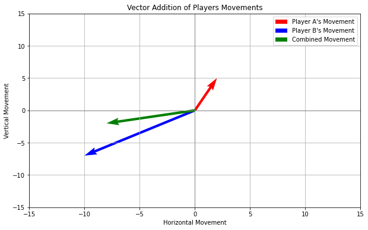

```python
# Plotting the vectors
plt.figure(figsize=(10, 6))
plt.quiver(0, 0, player_A_vector[0], player_A_vector[1], angles='xy', scale_units='xy', scale=1, color='r', label="Player A's Movement")
plt.quiver(0, 0, player_B_vector[0], player_B_vector[1], angles='xy', scale_units='xy', scale=1, color='b', label="Player B's Movement")
plt.quiver(0, 0, resultant_vector[0], resultant_vector[1], angles='xy', scale_units='xy', scale=1, color='g', label='Combined Movement')

plt.xlim(-15, 15)
plt.ylim(-15, 15)
plt.axvline(x=0, color='grey', lw=1)
plt.axhline(y=0, color='grey', lw=1)
plt.title('Vector Addition of Players Movements')
plt.xlabel('Horizontal Movement')
plt.ylabel('Vertical Movement')
plt.grid(True)
plt.legend()
plt.show()
```

#### Interpretation

From the visualization:

- The red arrow represents Player A's movement.
- The blue arrow represents Player B's movement.
- The green arrow represents the combined movement of both players, obtained by adding their individual vectors.

The direction and magnitude of the green arrow give us an idea of the overall movement when both players' movements are combined.

#### Conclusion

Through this exercise, we've visualized the concept of vector addition using a practical example from sports analytics. Vector addition is a fundamental operation in linear algebra and has applications in various fields, from physics to machine learning.

### Vector Subtraction

$v = \begin{pmatrix} v1\\ v2\\ v3\\ \end{pmatrix}$ And $w = \begin{pmatrix} w1\\ w2\\ w3\end{pmatrix}$ Add To  
$v - w = \begin{pmatrix} v1 - w1\\ v2 - w2\\ v3 - w3 \end{pmatrix}$

One vector can be subtracted from another vector of equal length to create a new third vector. As with addition, the new vector has the same length as the parent vectors and each element of the new vector is calculated as the subtraction of the elements at the same indices. The NumPy arrays can be directly subtracted in Python.

#### **Exercise 8** Understanding Vector Subtraction using Python

#### Problem Statement

Imagine you are a meteorologist analyzing wind patterns. You have two wind vectors: one representing the wind direction and speed in the morning and the other in the evening. You want to find out the change in wind direction and speed from morning to evening.

**Objective:** Subtract the morning wind vector from the evening wind vector and visualize the individual and resultant wind patterns on a 2D plane.

#### Step 1: Importing Necessary Libraries

```python
import numpy as np
import matplotlib.pyplot as plt
```

#### Step 2: Generating the Dataset

We'll create two vectors representing the wind patterns in the morning and evening.

```python
# Generating sample data
np.random.seed(0)

# Morning wind vector
morning_wind = np.array([np.random.randint(-10, 10), np.random.randint(-10, 10)])

# Evening wind vector
evening_wind = np.array([np.random.randint(-10, 10), np.random.randint(-10, 10)])
```

#### Step 3: Vector Subtraction

We'll subtract the morning wind vector from the evening wind vector to get the change in wind pattern.

```python
# Subtracting the vectors
wind_change = evening_wind - morning_wind
```

#### Step 4: Visualization

We'll visualize the individual wind patterns and their change on a 2D plane.

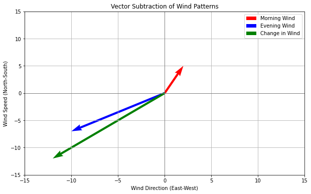

```python
# Plotting the vectors
plt.figure(figsize=(10, 6))
plt.quiver(0, 0, morning_wind[0], morning_wind[1], angles='xy', scale_units='xy', scale=1, color='r', label="Morning Wind")
plt.quiver(0, 0, evening_wind[0], evening_wind[1], angles='xy', scale_units='xy', scale=1, color='b', label="Evening Wind")
plt.quiver(0, 0, wind_change[0], wind_change[1], angles='xy', scale_units='xy', scale=1, color='g', label='Change in Wind')

plt.xlim(-15, 15)
plt.ylim(-15, 15)
plt.axvline(x=0, color='grey', lw=1)
plt.axhline(y=0, color='grey', lw=1)
plt.title('Vector Subtraction of Wind Patterns')
plt.xlabel('Wind Direction (East-West)')
plt.ylabel('Wind Speed (North-South)')
plt.grid(True)
plt.legend()
plt.show()
```

#### Interpretation

From the visualization:

- The red arrow represents the morning wind pattern.
- The blue arrow represents the evening wind pattern.
- The green arrow represents the change in wind pattern from morning to evening, obtained by subtracting the morning vector from the evening vector.

The direction and magnitude of the green arrow give us an idea of how the wind pattern changed throughout the day.

#### Conclusion

Through this exercise, we've visualized the concept of vector subtraction using a practical example from meteorology. Vector subtraction, like vector addition, is a foundational operation in linear algebra and is crucial in various scientific and engineering applications.

#### Supported properties by Vector Addition and Vector Subtraction.

1. Vector addition is commutative: $a + b = b + a.$
2. Vector addition is associative: $(a + b) + c = a + (b + c)$. We can therefore write both as $a + b + c.$
3. $a + 0 = 0 + a = a.$ Adding the zero vector to a vector has no effect.
4. $a − a = 0.$ Subtracting a vector from itself yields the zero vector.

### Inner product or dot product

We can calculate the sum of the multiplied elements of two vectors of the same length to give a scalar. This is called the dot product, named because of the dot operator used when describing the operation. The (standard) inner product (also called dot product) of two n-vectors is defined as the scalar.

$A^tb$ = $a_1b_1+a_2b_2+a_3b_3+......+a_nb_n$.

We can calculate the dot product between two vectors in Python using the dot() function on a NumPy array.

#### **Exercise 9** Understanding the Inner Product (Dot Product) using Python

#### Problem Statement

Imagine you are a data analyst at a sports equipment company. You have two vectors: one representing the number of units sold for different products, and the other representing the price per unit of those products. You want to find out the total revenue generated from these products.

**Objective:** Compute the dot product of the units sold vector and the price per unit vector to determine the total revenue.

#### Step 1: Importing Necessary Libraries

```python
import numpy as np
import matplotlib.pyplot as plt
```

#### Step 2: Generating the Dataset

We'll create two vectors: one representing the number of units sold for different products and the other representing the price per unit of those products.

```python
# Generating sample data
np.random.seed(0)

# Vector representing units sold for products A, B, C, and D
units_sold = np.array([np.random.randint(50, 100), np.random.randint(30, 70), np.random.randint(20, 50), np.random.randint(10, 30)])

# Vector representing price per unit for products A, B, C, and D
price_per_unit = np.array([np.random.randint(10, 20), np.random.randint(20, 30), np.random.randint(30, 40), np.random.randint(40, 50)])
```

#### Step 3: Computing the Dot Product

We'll compute the dot product of the two vectors to determine the total revenue.

```python
# Computing the dot product
total_revenue = np.dot(units_sold, price_per_unit)
```

#### Step 4: Visualization

We'll visualize the units sold and price per unit for each product and display the total revenue.

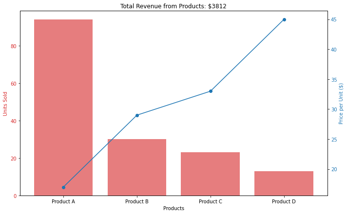

```python
# Plotting the data
products = ['Product A', 'Product B', 'Product C', 'Product D']

fig, ax1 = plt.subplots(figsize=(10, 6))

color = 'tab:red'
ax1.set_xlabel('Products')
ax1.set_ylabel('Units Sold', color=color)
ax1.bar(products, units_sold, color=color, alpha=0.6, label='Units Sold')
ax1.tick_params(axis='y', labelcolor=color)

ax2 = ax1.twinx()
color = 'tab:blue'
ax2.set_ylabel('Price per Unit ($)', color=color)
ax2.plot(products, price_per_unit, color=color, marker='o', label='Price per Unit ($)')
ax2.tick_params(axis='y', labelcolor=color)

fig.tight_layout()
plt.title(f'Total Revenue from Products: ${total_revenue}')
plt.show()
```

#### Interpretation

From the visualization:

- The red bars represent the number of units sold for each product.
- The blue line represents the price per unit for each product.
- The total revenue, calculated as the dot product of the units sold and price per unit vectors, gives us the overall income from the sales of these products.

#### Conclusion

Through this exercise, we've visualized and computed the dot product of two vectors, demonstrating its practical application in determining total revenue from product sales. The dot product is a fundamental operation in linear algebra with numerous applications in various domains.

### Properties Supported by Inner Product

The inner product satisfies some simple properties that are easily verified from the definition. If a, b, and c are vectors of the same size, and $γ$ is a scalar, we have the following.

1. Commutativity. $a^Tb = b^T a$. The order of the two vector arguments in the inner product does not matter.
2. Associativity with scalar multiplication. $(γa)^Tb = γ(a^Tb)$, so we can write both as $γa^Tb$.
3. Distributivity with vector addition. $(a+b)^Tc = a^Tc+b^Tc.$ The inner product can be distributed across vector addition.

### Vector Multiplication

$v = \begin{pmatrix} v1\\ v2\\ v3\\ \end{pmatrix}$ And $w = \begin{pmatrix} w1\\ w2\\ w3\end{pmatrix}$ Add To  
$v * w = \begin{pmatrix} v1 * w1\\ v2 * w2\\ v3 * w3 \end{pmatrix}$

Two vectors of equal length can be multiplied together. As with addition and subtraction, this operation is performed element-wise to result in a new vector of the same length. We can perform this operation directly in NumPy.

#### **Exercise 10** Understanding Vector Multiplication using Python

#### Problem Statement

Imagine you are an agronomist analyzing the yield of different crops in a farm. You have two vectors: one representing the area (in acres) allocated for each crop, and the other representing the yield (in tons per acre) of those crops. You want to find out the total yield for each crop.

**Objective:** Multiply the area vector with the yield vector element-wise to determine the total yield for each crop.

#### Step 1: Importing Necessary Libraries

```python
import numpy as np
import matplotlib.pyplot as plt
```

#### Step 2: Generating the Dataset

We'll create two vectors: one representing the area allocated for different crops and the other representing the yield of those crops.

```python
# Generating sample data
np.random.seed(0)

# Vector representing area allocated for crops A, B, C, and D (in acres)
area_allocated = np.array([np.random.randint(5, 15), np.random.randint(10, 20), np.random.randint(15, 25), np.random.randint(20, 30)])

# Vector representing yield for crops A, B, C, and D (in tons per acre)
crop_yield = np.array([np.random.uniform(1.5, 2.5), np.random.uniform(2.0, 3.0), np.random.uniform(2.5, 3.5), np.random.uniform(3.0, 4.0)])
```

#### Step 3: Vector Multiplication

We'll multiply the two vectors element-wise to determine the total yield for each crop.

```python
# Element-wise multiplication of the vectors
total_yield = np.multiply(area_allocated, crop_yield)
```

#### Step 4: Visualization

We'll visualize the area allocated and yield for each crop and display the total yield.

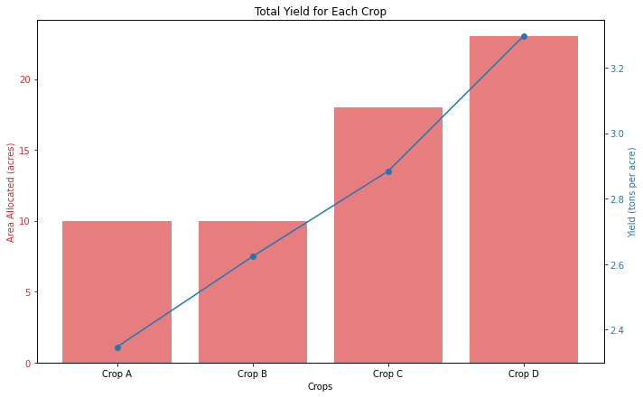

```
Total yield for Crop A: 23.47 tons
Total yield for Crop B: 26.24 tons
Total yield for Crop C: 51.92 tons
Total yield for Crop D: 75.84 tons
```

```python
# Plotting the data
crops = ['Crop A', 'Crop B', 'Crop C', 'Crop D']

fig, ax1 = plt.subplots(figsize=(10, 6))

color = 'tab:red'
ax1.set_xlabel('Crops')
ax1.set_ylabel('Area Allocated (acres)', color=color)
ax1.bar(crops, area_allocated, color=color, alpha=0.6, label='Area Allocated (acres)')
ax1.tick_params(axis='y', labelcolor=color)

ax2 = ax1.twinx()
color = 'tab:blue'
ax2.set_ylabel('Yield (tons per acre)', color=color)
ax2.plot(crops, crop_yield, color=color, marker='o', label='Yield (tons per acre)')
ax2.tick_params(axis='y', labelcolor=color)

fig.tight_layout()
plt.title('Total Yield for Each Crop')
plt.show()

# Displaying the total yield
for crop, yield_val in zip(crops, total_yield):
    print(f"Total yield for {crop}: {yield_val:.2f} tons")
```

#### Interpretation

From the visualization:

- The red bars represent the area allocated for each crop.
- The blue line represents the yield per acre for each crop.
- The total yield for each crop is calculated by multiplying the area allocated with the yield per acre, giving us the overall production for each crop.

#### Conclusion

Through this exercise, we've visualized and computed the element-wise multiplication of two vectors, demonstrating its practical application in determining total yield from different crops. Element-wise vector multiplication is a fundamental operation in linear algebra with numerous practical applications.

### Vector Division

Vector division isn't defined in the same way as scalar division. This is because vectors have both magnitude and direction, and it's not clear what dividing the direction of one vector by another would mean.

However, there are a few operations related to division that you can perform with vectors:

#### 1. Dot Product (Scalar Product)

This gives a scalar result from the multiplication of two vectors, but it doesn't really correspond to division. Given two vectors ( $\mathbf{A}$ ) and ( $\mathbf{B}$ ), their dot product is:

$\mathbf{A} \cdot \mathbf{B} = |\mathbf{A}| |\mathbf{B}| \cos(\theta)$

where ( $\theta$ ) is the angle between the two vectors.

#### 2. Cross Product (Vector Product)

This gives another vector as a result. For two vectors ( \mathbf{A} ) and ( \mathbf{B} ) in three-dimensional space, their cross product is:

$\mathbf{A} \times \mathbf{B} = |\mathbf{A}| |\mathbf{B}| \sin(\theta) \mathbf{n}$

where ( $\mathbf{n}$ ) is the unit vector perpendicular to the plane containing ( $\mathbf{A}$ ) and ( $\mathbf{B}$ ).

#### 3. Scalar Division

You can divide a vector by a scalar. For a vector ( \mathbf{V} ) and a scalar ( a ), the result is another vector where each component of ( $\mathbf{V}$ ) is divided by ( a ).

If you're trying to "divide" one vector by another, you might be looking to project one vector onto another, which isn't exactly division, but it can be related. For instance, the projection of ( $\mathbf{A}$ ) onto ( $\mathbf{B}$ ) can be found using the formula:

$\text{proj}_{\mathbf{B}} \mathbf{A} = \frac{\mathbf{A} \cdot \mathbf{B}}{\mathbf{B} \cdot \mathbf{B}} \mathbf{B}$

In short, there isn't a standard "vector division" operation analogous to scalar division. The operations you perform with vectors depend on the specific problem you're trying to solve.

#### **Exercise 11** Understanding Vector Division using Python

#### Problem Statement

Imagine you are a nutritionist analyzing the calorie content of different food items. You have two vectors: one representing the total calories for each food item, and the other representing the serving size (in grams) of those items. You want to find out the calorie content per gram for each food item.

**Objective:** Divide the total calories vector by the serving size vector element-wise to determine the calorie content per gram for each food item.

#### Step 1: Importing Necessary Libraries

```python
import numpy as np
import matplotlib.pyplot as plt
```

#### Step 2: Generating the Dataset

We'll create two vectors: one representing the total calories for different food items and the other representing the serving size of those items.

```python
# Generating sample data
np.random.seed(0)

# Vector representing total calories for food items A, B, C, and D
total_calories = np.array([np.random.randint(150, 250), np.random.randint(100, 200), np.random.randint(50, 150), np.random.randint(200, 300)])

# Vector representing serving size for food items A, B, C, and D (in grams)
serving_size = np.array([np.random.randint(100, 150), np.random.randint(50, 100), np.random.randint(30, 70), np.random.randint(120, 180)])
```

#### Step 3: Vector Division

We'll divide the two vectors element-wise to determine the calorie content per gram for each food item.

```python
# Element-wise division of the vectors
calories_per_gram = np.divide(total_calories, serving_size)
```

#### Step 4: Visualization

We'll visualize the total calories and serving size for each food item and display the calorie content per gram.

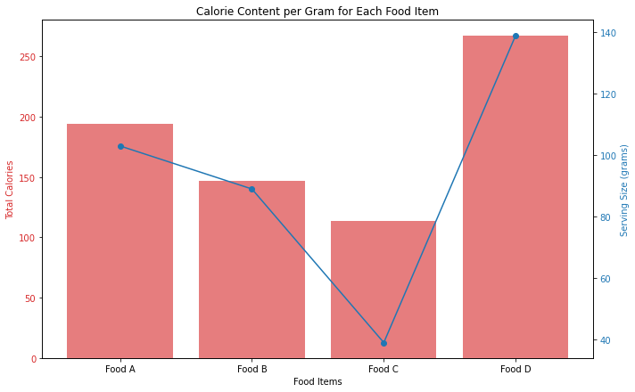

```
Calorie content per gram for Food A: 1.88 calories/g
Calorie content per gram for Food B: 1.65 calories/g
Calorie content per gram for Food C: 2.92 calories/g
Calorie content per gram for Food D: 1.92 calories/g
```

```python
# Plotting the data
food_items = ['Food A', 'Food B', 'Food C', 'Food D']

fig, ax1 = plt.subplots(figsize=(10, 6))

color = 'tab:red'
ax1.set_xlabel('Food Items')
ax1.set_ylabel('Total Calories', color=color)
ax1.bar(food_items, total_calories, color=color, alpha=0.6, label='Total Calories')
ax1.tick_params(axis='y', labelcolor=color)

ax2 = ax1.twinx()
color = 'tab:blue'
ax2.set_ylabel('Serving Size (grams)', color=color)
ax2.plot(food_items, serving_size, color=color, marker='o', label='Serving Size (grams)')
ax2.tick_params(axis='y', labelcolor=color)

fig.tight_layout()
plt.title('Calorie Content per Gram for Each Food Item')
plt.show()

# Displaying the calorie content per gram
for food, cal_per_g in zip(food_items, calories_per_gram):
    print(f"Calorie content per gram for {food}: {cal_per_g:.2f} calories/g")
```

#### Interpretation

From the visualization:

- The red bars represent the total calories for each food item.
- The blue line represents the serving size in grams for each food item.
- The calorie content per gram for each food item is calculated by dividing the total calories by the serving size, giving us the calorie density for each item.

#### Conclusion

Through this exercise, we've visualized and computed the element-wise division of two vectors, demonstrating its practical application in determining calorie content per gram for different food items. Element-wise vector division is a fundamental operation in linear algebra with numerous practical applications.

### Vector-Scalar Multiplication

A vector can be multiplied by a scalar, in effect scaling the magnitude of the vector. The multiplication is performed on each element of the vector to result in a new scaled vector of the same length.

#### **Exercise 12** Understanding Vector-Scalar Multiplication using Python

#### Problem Statement

Imagine you are a financial analyst working for a company that sells products online. You have a vector representing the sales (in USD) of a particular product over a week. Due to an upcoming sale, you expect that the sales will increase by 20%.

**Objective:** Multiply the sales vector by a scalar (1.20) to project the expected sales for the next week.

#### Step 1: Importing Necessary Libraries

```python
import numpy as np
import matplotlib.pyplot as plt
```

#### Step 2: Generating the Dataset

We'll create a vector representing the sales of a product over a week.

```python
# Generating sample data
np.random.seed(0)

# Vector representing sales for a product over a week (in USD)
sales = np.random.randint(500, 1000, 7)
```

#### Step 3: Vector-Scalar Multiplication

We'll multiply the sales vector by a scalar (1.20) to project the expected sales for the next week.

```python
# Scalar multiplication
expected_sales = sales * 1.20
```

#### Step 4: Visualization

We'll visualize the current sales and the projected sales for the next week.

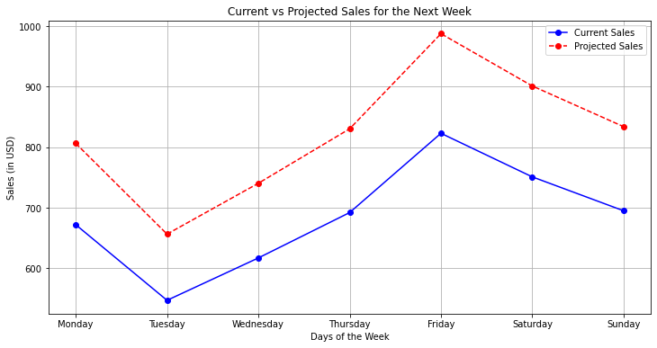

```python
# Plotting the data
days = ['Monday', 'Tuesday', 'Wednesday', 'Thursday', 'Friday', 'Saturday', 'Sunday']

plt.figure(figsize=(12, 6))
plt.plot(days, sales, marker='o', label='Current Sales', color='blue')
plt.plot(days, expected_sales, marker='o', linestyle='--', label='Projected Sales', color='red')
plt.xlabel('Days of the Week')
plt.ylabel('Sales (in USD)')
plt.title('Current vs Projected Sales for the Next Week')
plt.legend()
plt.grid(True)
plt.show()
```

#### Interpretation

From the visualization:

- The blue line represents the current sales for each day of the week.
- The red dashed line represents the projected sales for the next week, considering a 20% increase due to an upcoming sale.

The projected sales are consistently higher than the current sales across all days, indicating the potential impact of the sale on the product's revenue.

#### Conclusion

Through this exercise, we've visualized and computed the multiplication of a vector by a scalar, demonstrating its practical application in projecting sales figures. Vector-scalar multiplication is a fundamental operation in linear algebra with numerous real-world applications.

### **Vectors Norms**

The length of the vector is referred to as the vector norm or the vector’s magnitude.

**Types of norms**

1. Vector L1 Norm
2. Vector L2 Norm
3. Vector Max Norm

### L1 Norm

The L1 norm is calculated as the sum of the absolute vector values, where the absolute value of a scalar uses the notation $\|x\|$. In effect, the norm is a calculation of the Manhattan distance from the origin of the vector space.

#### **Exercise 13** Understanding L1 Norm using Python

#### Problem Statement

Imagine you are a data scientist working on feature selection for a machine learning model. You have a vector representing the weights of features in a model. To understand the importance of each feature, you decide to compute the L1 norm of the weights vector.

**Objective:** Compute the L1 norm of the weights vector, which can be used as a measure of feature importance.

#### Step 1: Importing Necessary Libraries

```python
import numpy as np
import matplotlib.pyplot as plt
```

#### Step 2: Generating the Dataset

We'll create a vector representing the weights of features in a model.

```python
# Generating sample data
np.random.seed(0)

# Vector representing weights of features in a model
weights = np.random.randn(5)
```

#### Step 3: Computing the L1 Norm

The L1 norm of a vector is the sum of the absolute values of its elements. We'll compute the L1 norm of the weights vector.

```python
# Computing L1 norm
l1_norm = np.linalg.norm(weights, 1)
```

#### Step 4: Visualization

We'll visualize the weights of the features and highlight the L1 norm.

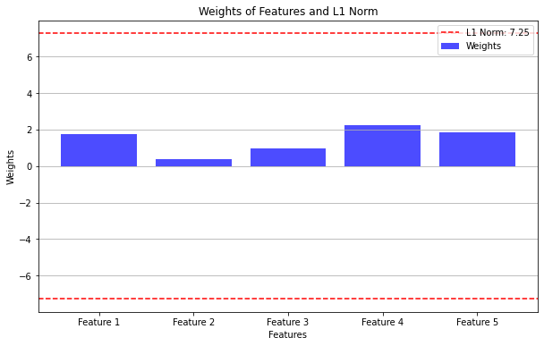

```python
# Plotting the data
features = [f'Feature {i+1}' for i in range(len(weights))]

plt.figure(figsize=(10, 6))
plt.bar(features, weights, color='blue', alpha=0.7, label='Weights')
plt.axhline(y=l1_norm, color='red', linestyle='--', label=f'L1 Norm: {l1_norm:.2f}')
plt.axhline(y=-l1_norm, color='red', linestyle='--')
plt.xlabel('Features')
plt.ylabel('Weights')
plt.title('Weights of Features and L1 Norm')
plt.legend()
plt.grid(axis='y')
plt.show()
```

#### Interpretation

From the visualization:

- The blue bars represent the weights of each feature in the model.
- The red dashed lines represent the positive and negative values of the L1 norm.

The L1 norm gives us a measure of the "size" or "magnitude" of the weights vector. In the context of feature selection, a higher L1 norm might indicate that the features have significant weights, suggesting their importance in the model.

#### Conclusion

Through this exercise, we've visualized and computed the L1 norm of a vector, demonstrating its potential application in understanding feature importance in machine learning models. The L1 norm is a fundamental concept in linear algebra and has various applications in data science and machine learning.

### L2 Norm

The L 2 norm calculates the distance of the vector coordinate from the origin of the vector space. As such, it is also known as the Euclidean norm as it is calculated as the Euclidean distance from the origin. The result is a positive distance value. The L 2 norm is calculated as the square root of the sum of the squared vector values.

$\|v\|$ = $\sqrt{a1^2 + a2^2 + a3^3}$`

#### **Exercise 14** Understanding L2 Norm using Python

#### Problem Statement

You are a data scientist working on a recommendation system. You have two vectors representing user preferences for two different users. To understand how similar these two users are in terms of preferences, you decide to compute the difference between their preference vectors and then calculate the L2 norm of this difference.

**Objective:** Compute the L2 norm of the difference between two user preference vectors to gauge user similarity.

#### Step 1: Importing Necessary Libraries

```python
import numpy as np
import matplotlib.pyplot as plt
```

#### Step 2: Generating the Dataset

We'll create two vectors representing the preferences of two users for a set of products.

```python
# Generating sample data
np.random.seed(0)

# Vectors representing preferences of two users for a set of products (scaled between 0 and 1)
user1_preferences = np.random.rand(5)
user2_preferences = np.random.rand(5)
```

#### Step 3: Computing the L2 Norm

The L2 norm (or Euclidean norm) of a vector is the square root of the sum of the squares of its elements. We'll compute the difference between the two user preference vectors and then calculate its L2 norm.

```python
# Computing difference between user preferences
difference = user1_preferences - user2_preferences

# Computing L2 norm
l2_norm = np.linalg.norm(difference)
```

#### Step 4: Visualization

We'll visualize the preferences of the two users and highlight the L2 norm of their difference.

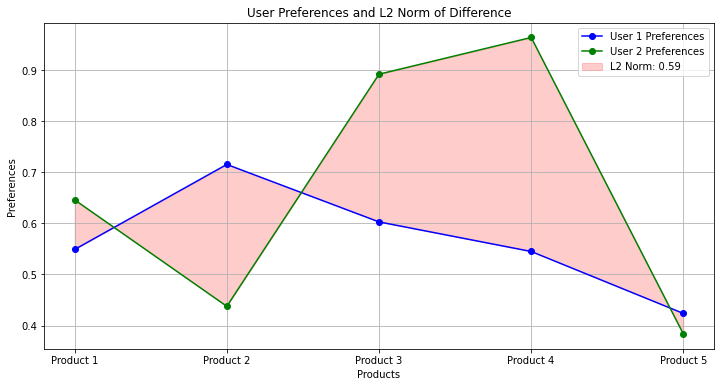

```python
# Plotting the data
products = [f'Product {i+1}' for i in range(len(user1_preferences))]

plt.figure(figsize=(12, 6))
plt.plot(products, user1_preferences, marker='o', label='User 1 Preferences', color='blue')
plt.plot(products, user2_preferences, marker='o', label='User 2 Preferences', color='green')
plt.fill_between(products, user1_preferences, user2_preferences, color='red', alpha=0.2, label=f'L2 Norm: {l2_norm:.2f}')
plt.xlabel('Products')
plt.ylabel('Preferences')
plt.title('User Preferences and L2 Norm of Difference')
plt.legend()
plt.grid(True)
plt.show()
```

#### Interpretation

From the visualization:

- The blue line represents the preferences of User 1 for different products.
- The green line represents the preferences of User 2 for the same products.
- The shaded region between the two lines represents the difference in preferences, with the L2 norm quantifying the overall magnitude of this difference.

The L2 norm gives us a measure of the "distance" or "difference" between the two user preference vectors. A smaller L2 norm indicates that the two users have similar preferences, while a larger L2 norm suggests more distinct preferences.

#### Conclusion

Through this exercise, we've visualized and computed the L2 norm of the difference between two vectors, demonstrating its potential application in understanding user similarity in recommendation systems. The L2 norm is a fundamental concept in linear algebra and plays a crucial role in various machine learning algorithms.

### Max Norm

The max norm is calculated as returning the maximum value of the vector, hence the name. Max norm of a vector is referred to as Linf where inf is a superscript and can be represented with the infinity symbol.

$\|v\|$ = $max$ $a1,a2,a3$

#### **Exercise 15** Understanding Max Norm using Python

#### Problem Statement

You are a data scientist working on an image processing task. You have a vector representing the pixel intensities of an image. To understand the maximum intensity value in the image, you decide to compute the Max Norm of the pixel intensity vector.

**Objective:** Compute the Max Norm of the pixel intensity vector, which will give you the maximum pixel intensity in the image.

#### Step 1: Importing Necessary Libraries

```python
import numpy as np
import matplotlib.pyplot as plt
```

#### Step 2: Generating the Dataset

We'll create a vector representing the pixel intensities of an image. The pixel intensities will be random values between 0 (black) and 255 (white).

```python
# Generating sample data
np.random.seed(0)

# Vector representing pixel intensities of an image (scaled between 0 and 255)
pixel_intensities = np.random.randint(0, 256, 50)
```

#### Step 3: Computing the Max Norm

The Max Norm of a vector is simply the maximum absolute value among its elements. We'll compute the Max Norm of the pixel intensity vector.

```python
# Computing Max Norm
max_norm = np.linalg.norm(pixel_intensities, np.inf)
```

#### Step 4: Visualization

We'll visualize the pixel intensities and highlight the Max Norm.

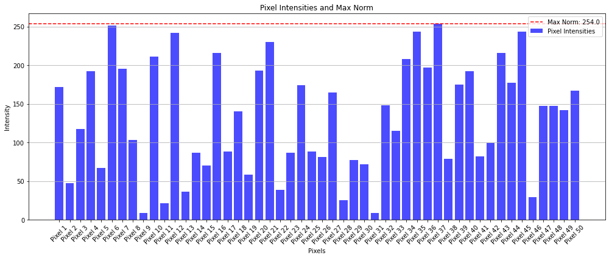

```python
# Plotting the data
pixels = [f'Pixel {i+1}' for i in range(len(pixel_intensities))]

plt.figure(figsize=(14, 6))
plt.bar(pixels, pixel_intensities, color='blue', alpha=0.7, label='Pixel Intensities')
plt.axhline(y=max_norm, color='red', linestyle='--', label=f'Max Norm: {max_norm}')
plt.xlabel('Pixels')
plt.ylabel('Intensity')
plt.title('Pixel Intensities and Max Norm')
plt.xticks(rotation=45)
plt.legend()
plt.grid(axis='y')
plt.tight_layout()
plt.show()
```

#### Interpretation

From the visualization:

- The blue bars represent the intensities of individual pixels in the image.
- The red dashed line represents the Max Norm, which is the maximum pixel intensity in the image.

The Max Norm gives us a measure of the maximum intensity value in the image. In image processing tasks, understanding the range of pixel intensities can be crucial for tasks like normalization, thresholding, etc.

#### Conclusion

Through this exercise, we've visualized and computed the Max Norm of a vector, demonstrating its potential application in image processing tasks. The Max Norm is a simple yet powerful concept in linear algebra that can provide insights into the range of values in a dataset.

#### **Exercise 16: Understanding Vector Operations using Python**

#### Problem Statement

You are a data scientist working on a physics simulation. You have two vectors representing forces acting on an object in a 2D plane. Your task is to compute the resultant force by performing various vector operations such as addition, subtraction, and scalar multiplication.

**Objective:** Compute and visualize the resultant force using vector operations.

#### Step 1: Importing Necessary Libraries

```python
import numpy as np
import matplotlib.pyplot as plt
```

#### Step 2: Generating the Dataset

We'll create two vectors representing forces acting on an object.

```python
# Generating sample data
np.random.seed(0)

# Vectors representing forces (in Newtons)
force_A = np.random.randint(1, 10, 2)
force_B = np.random.randint(1, 10, 2)
```

#### Step 3: Vector Operations

We'll perform the following vector operations:

1. Vector Addition
2. Vector Subtraction
3. Scalar Multiplication

```python
# Vector Addition
resultant_addition = force_A + force_B

# Vector Subtraction
resultant_subtraction = force_A - force_B

# Scalar Multiplication
scalar = 2
resultant_scalar_multiplication = scalar * force_A
```

#### Step 4: Visualization

We'll visualize the original forces and their resultant vectors.

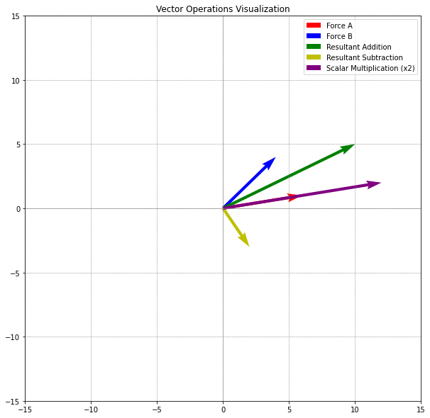

```python
# Plotting the data
plt.figure(figsize=(10, 10))
plt.quiver(0, 0, force_A[0], force_A[1], angles='xy', scale_units='xy', scale=1, color='r', label='Force A')
plt.quiver(0, 0, force_B[0], force_B[1], angles='xy', scale_units='xy', scale=1, color='b', label='Force B')
plt.quiver(0, 0, resultant_addition[0], resultant_addition[1], angles='xy', scale_units='xy', scale=1, color='g', label='Resultant Addition')
plt.quiver(0, 0, resultant_subtraction[0], resultant_subtraction[1], angles='xy', scale_units='xy', scale=1, color='y', label='Resultant Subtraction')
plt.quiver(0, 0, resultant_scalar_multiplication[0], resultant_scalar_multiplication[1], angles='xy', scale_units='xy', scale=1, color='purple', label=f'Scalar Multiplication (x{scalar})')

plt.xlim(-15, 15)
plt.ylim(-15, 15)
plt.axvline(x=0, color='grey',linewidth=0.5)
plt.axhline(y=0, color='grey',linewidth=0.5)
plt.grid(color = 'gray', linestyle = '--', linewidth = 0.5)
plt.title('Vector Operations Visualization')
plt.legend()
plt.show()
```

#### Interpretation

From the visualization:

- The red arrow represents Force A.
- The blue arrow represents Force B.
- The green arrow represents the resultant force due to vector addition.
- The yellow arrow represents the resultant force due to vector subtraction.
- The purple arrow represents the resultant force due to scalar multiplication.

Vector operations allow us to combine multiple forces to understand their combined effect on an object. In physics simulations, these operations are crucial to predict the movement and behavior of objects under various forces.

#### Conclusion

Through this exercise, we've visualized and computed various vector operations, demonstrating their potential application in physics simulations. Vector operations are foundational concepts in linear algebra and physics, providing insights into the combined effects of multiple forces or influences.

### **Matrix**

A matrix is a two-dimensional array of scalars with one or more columns and one or more rows.

Matrices are used throughout the field of machine learning in the description of algorithms and processes such as the input data variable $(X)$ when training an algorithm.

The notation for a matrix is often an uppercase letter, such as $A$, and entries are referred to by their two-dimensional subscript of row $(i)$ and column $(j)$, such as $ai,j$ . For example, we can define a 3-row, 2-column matrix:

A = $((a_1,_1,a_1,_2),(a_2,_1,a_2,_2),(a_3,_1,a_3,_2$).

It is more common to see matrices defined using a horizontal notation.  
$a = \begin{bmatrix} a_1,_1 & a_1,_2 \\ a_2,_1 & a_2,_2\\ a_3,_1 & a_3,_2 \end{bmatrix}$

#### **Exercise 17** Understanding Matrices using Python

#### Problem Statement

You are a data scientist working for a graphics company. You have been tasked with understanding the transformation of 2D objects using matrices. Your goal is to create a 2x2 matrix and use it to transform a set of 2D points representing a shape.

**Objective:** Create a 2x2 matrix, apply it to a set of 2D points, and visualize the transformation.

#### Step 1: Importing Necessary Libraries

```python
import numpy as np
import matplotlib.pyplot as plt
```

#### Step 2: Generating the Dataset

We'll create a set of 2D points representing a simple shape (a square).

```python
# Generating sample data
square_points = np.array([[0, 0], [0, 1], [1, 1], [1, 0], [0, 0]])
```

#### Step 3: Creating the Matrix

We'll create a 2x2 matrix that will be used to transform our shape.

```python
# Creating a 2x2 transformation matrix
transformation_matrix = np.array([[2, 0], [0, 1.5]])
```

#### Step 4: Applying the Matrix to the 2D Points

We'll apply the transformation matrix to our set of 2D points to get the transformed shape.

```python
# Transforming the square points using the matrix
transformed_points = np.dot(square_points, transformation_matrix)
```

#### Step 5: Visualization

We'll visualize the original shape and its transformation.

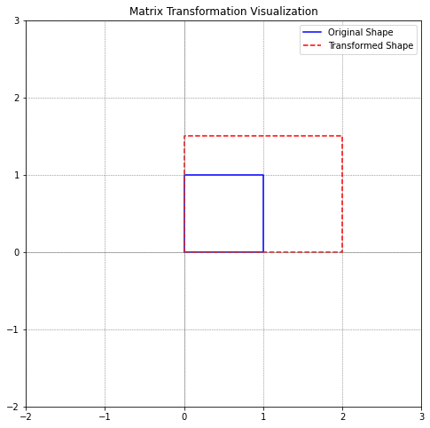

```python
# Plotting the data
plt.figure(figsize=(8, 8))
plt.plot(square_points[:, 0], square_points[:, 1], label='Original Shape', color='blue')
plt.plot(transformed_points[:, 0], transformed_points[:, 1], label='Transformed Shape', color='red', linestyle='--')
plt.xlim(-2, 3)
plt.ylim(-2, 3)
plt.axvline(x=0, color='grey',linewidth=0.5)
plt.axhline(y=0, color='grey',linewidth=0.5)
plt.grid(color = 'gray', linestyle = '--', linewidth = 0.5)
plt.title('Matrix Transformation Visualization')
plt.legend()
plt.show()
```

#### Interpretation

From the visualization:

- The blue shape represents our original set of 2D points.
- The red dashed shape represents the transformed set of 2D points after applying the matrix.

The transformation matrix has stretched our original shape along the x-axis by a factor of 2 and along the y-axis by a factor of 1.5. This demonstrates how matrices can be used to transform shapes in graphics and other applications.

#### Conclusion

Through this exercise, we've visualized and understood the concept of matrix transformations. Matrices are powerful tools in linear algebra and have wide-ranging applications in graphics, physics, and many other fields.

#### **Dimension Of Matrix**

Dimension of matrix is defined by number of rows and number of columns in the matrix.

#### **Exercise 18** Understanding the Dimension of Matrices using Python

#### Problem Statement

You are a data scientist working for a company that specializes in data storage and processing. You often deal with large datasets that are represented as matrices. To optimize storage and processing, you need to understand the dimensions of these matrices.

**Objective:** Create a matrix and determine its dimensions.

#### Step 1: Importing Necessary Libraries

```python
import numpy as np
```

#### Step 2: Generating the Dataset

We'll create a matrix with random values.

```python
# Generating a random matrix of size 4x5
np.random.seed(0)
matrix = np.random.randint(1, 10, size=(4, 5))
```

#### Step 3: Determining the Dimension of the Matrix

We'll use numpy's shape attribute to determine the dimension of our matrix.

```python
# Getting the dimension of the matrix
rows, columns = matrix.shape
```

#### Step 4: Visualization

While matrices themselves aren't typically visualized, for the sake of this exercise, we'll visualize the matrix using a heatmap to understand its structure.

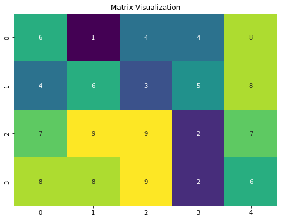

```python
import matplotlib.pyplot as plt
import seaborn as sns

# Plotting the matrix as a heatmap
plt.figure(figsize=(8, 6))
sns.heatmap(matrix, annot=True, cmap='viridis', cbar=False)
plt.title('Matrix Visualization')
plt.show()
```

#### Interpretation

From the generated matrix:

#### Conclusion

Through this exercise, we've learned how to determine the dimension of a matrix using Python. The dimension of a matrix gives us insights into its structure and is a fundamental concept in linear algebra with applications in various fields like data processing, graphics, and physics.

### Matrix Addition

Two matrices with the same dimensions can be added together to create a new third matrix.

$C = A + B$

The scalar elements in the resulting matrix are calculated as the addition of the elements in each of the matrices being added.

$c = \begin{bmatrix} a_1,_1+b_1,_1 & a_1,_2+b_1,_2 \\ a_2,_1+b_2,_1 & a_2,_2+b_2,_2\\ a_3,_1+b_3,_1 & a_3,_2+b_3,_2 \end{bmatrix}$

#### **Exercise 19** Understanding Matrix Addition using Python

#### Problem Statement

You are a data scientist working for a company that specializes in data analytics. You often deal with datasets that are represented as matrices. One of the tasks you frequently perform is combining datasets, which can be represented as matrix addition.

**Objective:** Create two matrices and perform their addition.

#### Step 1: Importing Necessary Libraries

```python
import numpy as np
```

#### Step 2: Generating the Datasets

We'll create two matrices with random values.

```python
# Generating two random matrices of size 3x3
np.random.seed(0)
matrix_A = np.random.randint(1, 10, size=(3, 3))
matrix_B = np.random.randint(1, 10, size=(3, 3))
```

#### Step 3: Performing Matrix Addition

We'll use numpy's addition operation to add the two matrices.

```python
# Adding the two matrices
matrix_C = matrix_A + matrix_B
```

#### Step 4: Visualization

We'll visualize the matrices using heatmaps to understand their structure and the result of their addition.

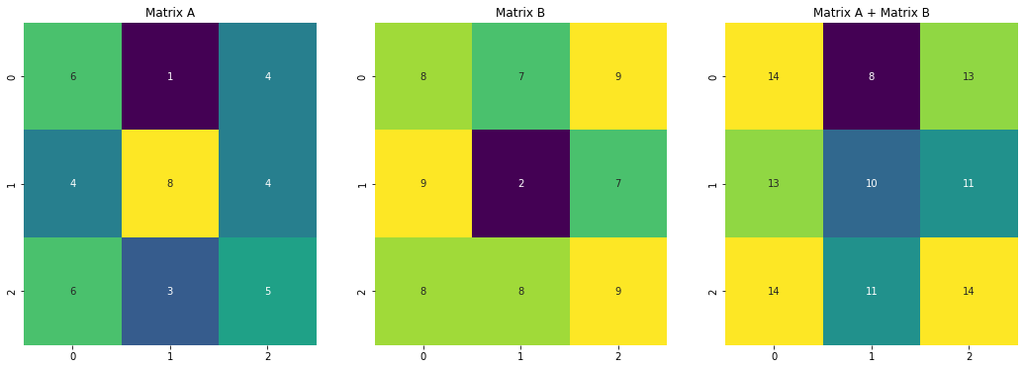

```python
import matplotlib.pyplot as plt
import seaborn as sns

# Plotting the matrices as heatmaps
fig, ax = plt.subplots(1, 3, figsize=(18, 6))

sns.heatmap(matrix_A, annot=True, cmap='viridis', cbar=False, ax=ax[0])
ax[0].set_title('Matrix A')

sns.heatmap(matrix_B, annot=True, cmap='viridis', cbar=False, ax=ax[1])
ax[1].set_title('Matrix B')

sns.heatmap(matrix_C, annot=True, cmap='viridis', cbar=False, ax=ax[2])
ax[2].set_title('Matrix A + Matrix B')

plt.show()
```

#### Interpretation

From the visualizations:

- The first heatmap represents Matrix A.
- The second heatmap represents Matrix B.
- The third heatmap represents the result of adding Matrix A and Matrix B.

Each element in the resulting matrix is the sum of the corresponding elements from Matrix A and Matrix B. This demonstrates the element-wise addition property of matrices.

#### Conclusion

Through this exercise, we've visualized and understood the concept of matrix addition. Matrix addition is a fundamental operation in linear algebra with applications in various fields like data analytics, graphics, and physics.

### Matrix Subtraction

Similarly, one matrix can be subtracted from another matrix with the same dimensions.

$C = A - B$

The scalar elements in the resulting matrix are calculated as the subtraction of the elements in each of the matrices.

$c = \begin{bmatrix} a_1,_1-b_1,_1 & a_1,_2-b_1,_2 \\ a_2,_1-b_2,_1 & a_2,_2-b_2,_2\\ a_3,_1-b_3,_1 & a_3,_2-b_3,_2 \end{bmatrix}$

#### **Exercise 20** Understanding Matrix Subtraction using Python

#### Problem Statement

You are a data scientist working for a financial firm. You often deal with datasets that are represented as matrices. One of the tasks you frequently perform is calculating the difference between datasets, which can be represented as matrix subtraction.

**Objective:** Create two matrices and perform their subtraction.

#### Step 1: Importing Necessary Libraries

```python
import numpy as np
```

#### Step 2: Generating the Datasets

We'll create two matrices with random values.

```python
# Generating two random matrices of size 3x3
np.random.seed(0)
matrix_X = np.random.randint(1, 10, size=(3, 3))
matrix_Y = np.random.randint(1, 10, size=(3, 3))
```

#### Step 3: Performing Matrix Subtraction

We'll use numpy's subtraction operation to subtract the two matrices.

```python
# Subtracting matrix_Y from matrix_X
matrix_Z = matrix_X - matrix_Y
```

#### Step 4: Visualization

We'll visualize the matrices using heatmaps to understand their structure and the result of their subtraction.

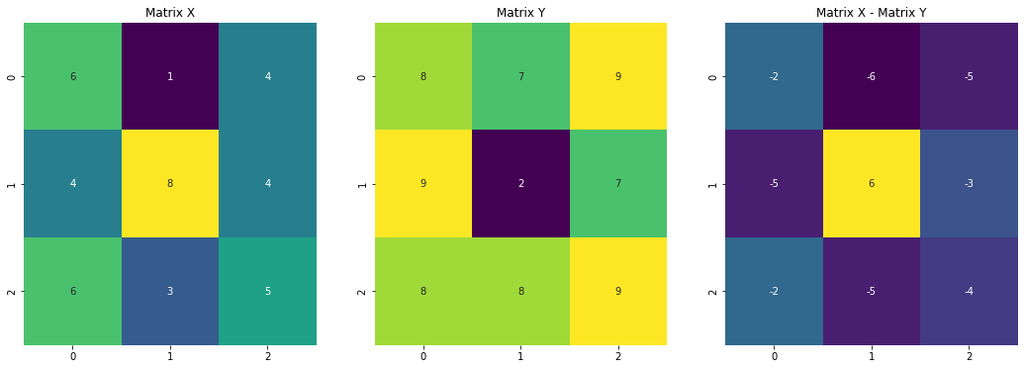

```python
import matplotlib.pyplot as plt
import seaborn as sns

# Plotting the matrices as heatmaps
fig, ax = plt.subplots(1, 3, figsize=(18, 6))

sns.heatmap(matrix_X, annot=True, cmap='viridis', cbar=False, ax=ax[0])
ax[0].set_title('Matrix X')

sns.heatmap(matrix_Y, annot=True, cmap='viridis', cbar=False, ax=ax[1])
ax[1].set_title('Matrix Y')

sns.heatmap(matrix_Z, annot=True, cmap='viridis', cbar=False, ax=ax[2])
ax[2].set_title('Matrix X - Matrix Y')

plt.show()
```

#### Interpretation

From the visualizations:

- The first heatmap represents Matrix X.
- The second heatmap represents Matrix Y.
- The third heatmap represents the result of subtracting Matrix Y from Matrix X.

Each element in the resulting matrix is the difference between the corresponding elements from Matrix X and Matrix Y. This demonstrates the element-wise subtraction property of matrices.

#### Conclusion

Through this exercise, we've visualized and understood the concept of matrix subtraction. Matrix subtraction is a fundamental operation in linear algebra with applications in various fields like finance, data analytics, and engineering.

### Matrix Multiplication

$C = A*B$

As with element-wise subtraction and addition, element-wise multiplication involves the multiplication of elements from each parent matrix to calculate the values in the new matrix.

$c = \begin{bmatrix} a_1,_1*b_1,_1 & a_1,_2*b_1,_2 \\ a_2,_1*b_2,_1 & a_2,_2*b_2,_2\\ a_3,_1*b_3,_1 & a_3,_2*b_3,_2 \end{bmatrix}$

#### **Exercise 21** Understanding Matrix Multiplication using Python

#### Problem Statement

You are a data scientist working for a tech company that specializes in graphics rendering. You often deal with transformation matrices that help in rendering 3D objects on a 2D screen. One of the fundamental operations you perform is matrix multiplication to combine various transformations.

**Objective:** Create two matrices and perform their multiplication.

#### Step 1: Importing Necessary Libraries

```python
import numpy as np
```

#### Step 2: Generating the Datasets

We'll create two matrices with random values.

```python
# Generating two random matrices of size 3x3
np.random.seed(0)
matrix_P = np.random.randint(1, 10, size=(3, 3))
matrix_Q = np.random.randint(1, 10, size=(3, 3))
```

#### Step 3: Performing Matrix Multiplication

We'll use numpy's `dot` function to multiply the two matrices.

```python
# Multiplying the two matrices
matrix_R = np.dot(matrix_P, matrix_Q)
```

#### Step 4: Visualization

We'll visualize the matrices using heatmaps to understand their structure and the result of their multiplication.

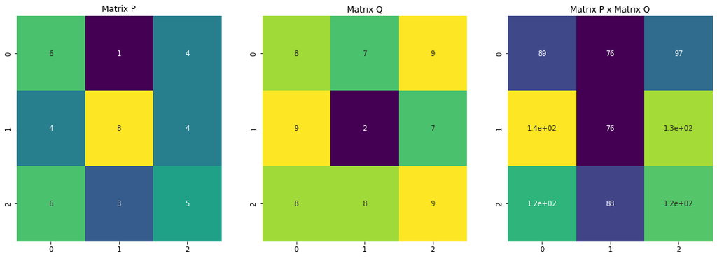

```python
import matplotlib.pyplot as plt
import seaborn as sns

# Plotting the matrices as heatmaps
fig, ax = plt.subplots(1, 3, figsize=(18, 6))

sns.heatmap(matrix_P, annot=True, cmap='viridis', cbar=False, ax=ax[0])
ax[0].set_title('Matrix P')

sns.heatmap(matrix_Q, annot=True, cmap='viridis', cbar=False, ax=ax[1])
ax[1].set_title('Matrix Q')

sns.heatmap(matrix_R, annot=True, cmap='viridis', cbar=False, ax=ax[2])
ax[2].set_title('Matrix P x Matrix Q')

plt.show()
```

#### Interpretation

From the visualizations:

- The first heatmap represents Matrix P.
- The second heatmap represents Matrix Q.
- The third heatmap represents the result of multiplying Matrix P with Matrix Q.

Matrix multiplication is not element-wise. Instead, each element in the resulting matrix is the sum of the products of elements from the rows of the first matrix and the columns of the second matrix.

#### Conclusion

Through this exercise, we've visualized and understood the concept of matrix multiplication. Matrix multiplication is a core operation in linear algebra with applications in various fields like graphics rendering, data transformation, and systems of linear equations.

### Matrix Division

Matrix division, as a direct analog to scalar division, is not defined. However, in the context of matrices, when we talk about "dividing" by a matrix, we usually refer to finding the inverse of the matrix and multiplying by that inverse.

Given two matrices, (A) and (B), the equation ($A \div B$) doesn't make direct sense. Instead, we would express the operation as multiplication by the inverse:

$A \times B^{-1}$

Assuming \$(B^{-1}$) (the inverse of (B)) exists.

#### Matrix Inverse

A matrix (B) has an inverse ($B^{-1}$) if and only if:

1. (B) is square (has the same number of rows and columns).
2. The determinant of (B) is not zero.

If ($B^{-1}$) exists, then the product ($B \times B^{-1} = I$), where (I) is the identity matrix of the same size as (B).

#### Application in Systems of Equations

If you're dealing with systems of equations, the idea of "dividing" by a matrix becomes more intuitive. Consider the system:

$ Ax = b $

To solve for (x), you can "multiply both sides" by the inverse of (A), assuming (A) is invertible:

$A^{-1}Ax = A^{-1}b$

Which simplifies to:

$x = A^{-1}b$

So, in this context, multiplying by the inverse matrix ($A^{-1}$) serves a similar purpose as dividing by a scalar in algebra.

#### Element-wise Division

It's also worth noting that for element-wise operations on matrices (operations performed element by element, similar to how array operations are done in programming), you could theoretically "divide" one matrix by another element-wise, as long as no element in the denominator matrix is zero. However, this operation is different from the matrix operations used in linear algebra and is more akin to array operations in programming.

#### **Exercise 22** Understanding Matrix Division using Python

#### Problem Statement

You are a data scientist working for a robotics company. You often deal with transformation matrices that help in determining robot movements. One of the operations you come across is the need to "undo" a transformation, which can be thought of as dividing by a matrix.

**Objective:** Create a matrix and its inverse, then multiply them to verify that they produce the identity matrix.

#### Step 1: Importing Necessary Libraries

```python
import numpy as np
```

#### Step 2: Generating the Dataset

We'll create a matrix with random values.

```python
# Generating a random matrix of size 3x3
np.random.seed(0)
matrix_S = np.random.randint(1, 10, size=(3, 3))
```

#### Step 3: Finding the Inverse

We'll use numpy's `inv` function to find the inverse of the matrix.

```python
from numpy.linalg import inv

# Finding the inverse of matrix_S
matrix_S_inv = inv(matrix_S)
```

#### Step 4: Multiplying Matrix with its Inverse

We'll multiply the matrix with its inverse and expect to get the identity matrix.

```python
# Multiplying the matrix with its inverse
identity_matrix = np.dot(matrix_S, matrix_S_inv)
```

#### Step 5: Visualization

We'll visualize the matrices using heatmaps to understand their structure and the result of their multiplication.

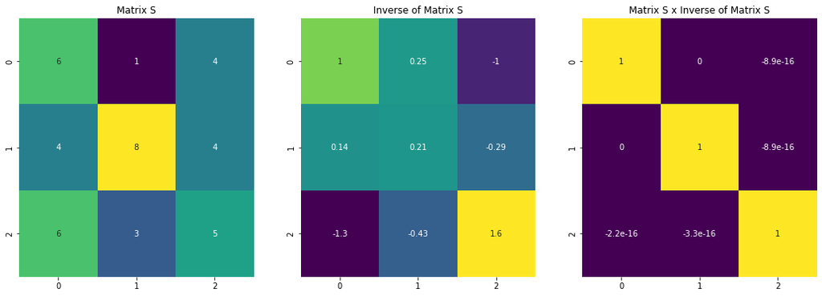

```python
import matplotlib.pyplot as plt
import seaborn as sns

# Plotting the matrices as heatmaps
fig, ax = plt.subplots(1, 3, figsize=(18, 6))

sns.heatmap(matrix_S, annot=True, cmap='viridis', cbar=False, ax=ax[0])
ax[0].set_title('Matrix S')

sns.heatmap(matrix_S_inv, annot=True, cmap='viridis', cbar=False, ax=ax[1])
ax[1].set_title('Inverse of Matrix S')

sns.heatmap(identity_matrix, annot=True, cmap='viridis', cbar=False, ax=ax[2])
ax[2].set_title('Matrix S x Inverse of Matrix S')

plt.show()
```

#### Interpretation

From the visualizations:

- The first heatmap represents Matrix S.
- The second heatmap represents the inverse of Matrix S.
- The third heatmap represents the result of multiplying Matrix S with its inverse.

The resulting matrix should be close to the identity matrix. This demonstrates that when a matrix is multiplied by its inverse, the result is the identity matrix.

#### Conclusion

Through this exercise, we've visualized and understood the concept of matrix inversion and how it relates to the idea of "division" in matrix operations. The ability to find matrix inverses and use them is crucial in many areas of science and engineering.

### Matrix-Matrix Multiplication

Matrix multiplication, also called the matrix dot product is more complicated than the previous operations and involves a rule as not all matrices can be multiplied together.

$C = A*B$ or $C = AB$

The number of columns $(n)$ in the first matrix $(A)$ must equal the number of rows $(m)$ in the second matrix $(B).$

For example, matrix A has the dimensions $m$ rows and $n$ columns and matrix $B$ has the dimensions $n$ and $k.$ The $n$ columns in $A$ and $n$ rows in $B$ are equal. The result is a new matrix with $m$ rows and $k$ columns. $C(m, k) = A(m, n) · B(n, k)$

One of the most important operations involving matrices is multiplication of two matrices. The matrix product of matrices $A$ and $B$ is a third matrix $C$. In order for this product to be defined, $A$ must have the same number of columns as $B$ has rows. If $A$ is of shape $m × n$ and $B$ is of shape $n × p,$ then $C$is of shape $m × p.$

$a = \begin{bmatrix} a_1,_1 & a_1,_2 \\ a_2,_1 & a_2,_2\\ a_3,_1 & a_3,_2 \end{bmatrix}$ $b = \begin{bmatrix} b_1,_1 & b_1,_2 \\ b_2,_1 & b_2,_2\\ \end{bmatrix}$

$a*b = \begin{bmatrix} a_1,_1*b_1,_1 + a_1,_2*b_2,_1 & a_1,_1 * b_1,_2 + a_1,_2 * b_2,_2 \\ a_2,_1*b_1,_1 + a_2,_2*b_2,_1 & a_2,_1 * b_1,_2 + a_2,_2 * b_2,_2\\ a_3,_1*b_1,_1 + a_3,_2*b_2,_1 & a_3,_1 * b_1,_2 + a_3,_2 * b_2,_2 \end{bmatrix}$

#### **Exercise 23** Understanding Matrix-Matrix Multiplication using Python

#### Problem Statement

You are a data scientist working for a game development company. You are tasked with developing a transformation pipeline that combines multiple transformations into one. This requires you to multiply transformation matrices together.

**Objective:** Create two matrices and perform their multiplication to obtain the resulting transformation matrix.

#### Step 1: Importing Necessary Libraries

```python
import numpy as np
```

#### Step 2: Generating the Datasets

We'll create two matrices with random values for our exercise.

```python
# Generating two random matrices of size 3x3
np.random.seed(0)
matrix_A = np.random.randint(1, 10, size=(3, 3))
matrix_B = np.random.randint(1, 10, size=(3, 3))
```

#### Step 3: Performing Matrix-Matrix Multiplication

We'll use numpy's `dot` function to multiply the two matrices.

```python
# Multiplying the two matrices
matrix_C = np.dot(matrix_A, matrix_B)
```

#### Step 4: Visualization

We'll visualize the matrices using heatmaps to understand their structure and the result of their multiplication.

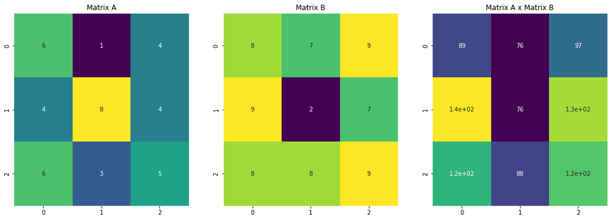

```python
import matplotlib.pyplot as plt
import seaborn as sns

# Plotting the matrices as heatmaps
fig, ax = plt.subplots(1, 3, figsize=(18, 6))

sns.heatmap(matrix_A, annot=True, cmap='viridis', cbar=False, ax=ax[0])
ax[0].set_title('Matrix A')

sns.heatmap(matrix_B, annot=True, cmap='viridis', cbar=False, ax=ax[1])
ax[1].set_title('Matrix B')

sns.heatmap(matrix_C, annot=True, cmap='viridis', cbar=False, ax=ax[2])
ax[2].set_title('Matrix A x Matrix B')

plt.show()
```

#### Interpretation

From the visualizations:

- The first heatmap represents Matrix A.
- The second heatmap represents Matrix B.
- The third heatmap represents the result of multiplying Matrix A with Matrix B.

Matrix multiplication is not element-wise. Instead, each element in the resulting matrix is the sum of the products of elements from the rows of the first matrix and the columns of the second matrix.

#### Conclusion

Through this exercise, we've visualized and understood the concept of matrix-matrix multiplication. This operation is fundamental in linear algebra and has applications in various fields like graphics rendering, data transformation, and systems of linear equations.

### Matrix Vector Multiplication

A matrix and a vector can be multiplied together as long as the rule of matrix multiplication is observed. Specifically, that the number of columns in the matrix must equal the number of items in the vector. As with matrix multiplication, the operation can be written using the dot notation. Because the vector only has one column, the result is always a vector.

$C = A *v$

The result is a vector with the same number of rows as the parent matrix.

$a = \begin{bmatrix} a_1,_1 & a_1,_2 \\ a_2,_1 & a_2,_2\\ a_3,_1 & a_3,_2 \end{bmatrix}$ $v = \begin{bmatrix} v_1 \\ v_2\\ \end{bmatrix}$ ----- $c = Av$ -----> $c = \begin{bmatrix} a_1,_1*v_1 + a_1,_2*v_2 \\ a_2,_1*v_1+ a_2,_2*v_2\\ a_3,_1*v_1 + a_3,_2*v_2 \end{bmatrix}$

#### **Exercise 24** Understanding Matrix-Vector Multiplication using Python

#### Problem Statement

You are a data scientist working for a company that specializes in computer graphics. One of the tasks you often encounter is transforming a point in 3D space using a transformation matrix. This involves multiplying a matrix with a vector.

**Objective:** Create a 3x3 matrix and a 3x1 vector. Perform matrix-vector multiplication to obtain the transformed vector.

#### Step 1: Importing Necessary Libraries

```python
import numpy as np
```

#### Step 2: Generating the Datasets

We'll create a 3x3 matrix and a 3x1 vector with random values for our exercise.

```python
# Generating a random 3x3 matrix and a 3x1 vector
np.random.seed(0)
matrix_M = np.random.randint(1, 10, size=(3, 3))
vector_v = np.random.randint(1, 10, size=(3, 1))
```

#### Step 3: Performing Matrix-Vector Multiplication

We'll use numpy's `dot` function to multiply the matrix with the vector.

```python
# Multiplying the matrix with the vector
transformed_vector = np.dot(matrix_M, vector_v)
```

#### Step 4: Visualization

We'll visualize the matrix, the original vector, and the transformed vector using bar plots to understand their structure and the result of their multiplication.

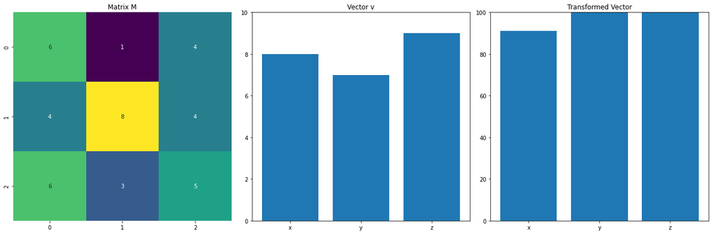

```python
import matplotlib.pyplot as plt

# Plotting the matrix, vector, and transformed vector
fig, ax = plt.subplots(1, 3, figsize=(18, 6))

sns.heatmap(matrix_M, annot=True, cmap='viridis', cbar=False, ax=ax[0])
ax[0].set_title('Matrix M')

ax[1].bar(['x', 'y', 'z'], vector_v.flatten())
ax[1].set_title('Vector v')
ax[1].set_ylim(0, 10)

ax[2].bar(['x', 'y', 'z'], transformed_vector.flatten())
ax[2].set_title('Transformed Vector')
ax[2].set_ylim(0, 100)

plt.tight_layout()
plt.show()
```

#### Interpretation

From the visualizations:

- The first heatmap represents Matrix M.
- The second bar plot represents the original Vector v.
- The third bar plot represents the result of multiplying Matrix M with Vector v.

Matrix-vector multiplication is used to transform the original vector. Each element in the resulting vector is the sum of the products of matrix rows and the vector's elements.

#### Conclusion

Through this exercise, we've visualized and understood the concept of matrix-vector multiplication. This operation is fundamental in linear algebra and is especially important in fields like computer graphics, where it's used to transform points in space.

#### Revised Date: October 28, 2023